# Data Types and Structures

Joel Ledford

Winter 2020

## Essential Information about R

R is an open source, **scripting** language. RStudio is a GUI (graphical user interface) that is frequently used to interact with R. You need R installed in order for RStudio to work.

Because R is a scripting language you don’t point and click to run commands. Instead, you write instructions that are used by the computer to complete an operation. This makes for excellent repeatability but makes it hard to learn at first because the instructions are specific. R is **not** tolerant of typos, puntuation errors, errant spaces, or other types of mistakes.

## Install the tidyverse

One strength of R is that there are thousands of add-on packages that perform specialized functions. The packages are referred to as libraries.

In this class, we will routinely use the library called the **tidyverse**. Libraries need to be installed in order to work, and whenever you update R you also need to update all of the packages that you use. In class, the tidyverse is pre-installed but at home you will need to install the package.

```r
#install.packages("tidyverse")
```

Here is another clever option.

```r
#if (!require('tidyverse')) install.packages('tidyverse'); library('tidyverse')
```

## Call the library

In order for the tidyverse or any other library to become active, it needs to be `called`.

```r
library("tidyverse")
```

## RMarkdown

Annotation of code is very important for programmers of all levels. When code is annotated, it is easy for others to understand and perhaps more importantly, easier for the person who wrote the code to understand when returning to a project days to years later. RMarkdown allows us to embed code in annotated chunks, including display of graphical output. The RMarkdown file can then be exported in a number of formats. If you have questions, the definitive guide is [here](https://bookdown.org/yihui/rmarkdown/).

I *love* RMarkdown. Spend some time learning to effectively use it for notes and reports.

## Practice

RMarkdown is one of many types of documents that can be created in RStudio. It is an extremely helpful way to build code because it will display the code, its output, and any text that you wish to add.

1. In RStudio, open a new markdown document: **File>New File>R Markdown**
2. There is some generic information at the start of the file that we don’t need. Delete lines 12 through 31 to clean things up. 3. Insert a new R code chunk by clicking on the green `insert` tab and selecting R.
3. Copy and paste the following into the new code chunk.

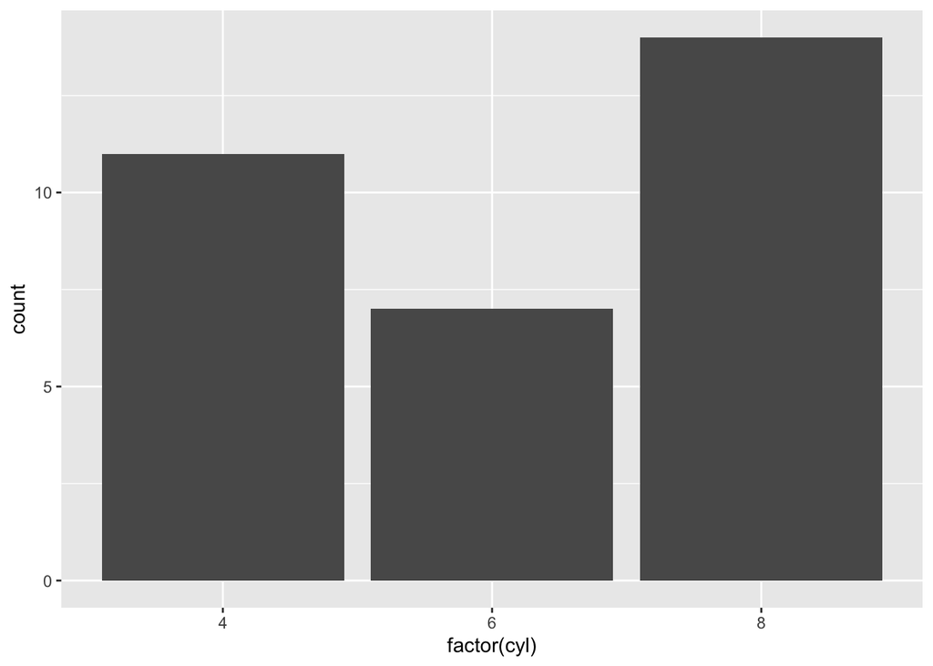

```r
ggplot(mtcars, aes(x = factor(cyl))) +
    geom_bar()
```

5. Now `knit` the file together using the knit button at the top of the page.

## Help

R is a flexible programming language that is used by scientists worldwide. Thousands of packages are available to perform specific analyses and there is a large community of people willing to help if you have problems.

Adding a ‘?’ before a command will bring up the associated help document.

```r
?mean
```

[Stack Overflow](https://stackoverflow.com/) is an extremely helpful resource for R programming type questions. Stack Overflow questions and answers can usually be found by Googling your R related question and including ‘R’ in the search phrase. This technique also works for R error messages. Just be sure to thoroughly look for help before posting questions to Stack Overflow or related forums.

## Learning Goals

*At the end of this exercise, you will be able to:*  
1. Solve arithmetic operations in R.  
2. Define an object in R; assign values to objects.  
3. Learn best practices in the naming of objects and other R programming conventions.  
4. Learn the differences between the types of data used in R.  
5. Perform simple operations using vectors.

## Arithmetic

You can use R as a calculator; just enter the operation into a new code chunk. Order of operations applies and you don’t need to add an ‘=’ sign.

```r
4*12
```

```
## [1] 48
```

```r
(4*12)/2
```

```
## [1] 24
```

Statistics are what R was originally written for, so it will pretty much do anything you need and there are thousands of packages for specialized statistics depending on your needs.

```r
mean(4, 6, 8, 5, 6, 7, 7, 7)
```

```
## [1] 4
```

## Objects

In order to access the potential of R we need to assign values or other types of data to `objects`. There is a specific format that I want you to follow, so please pay close attention.

Assign a value to object ‘x’. The ‘<-’ symbol is read as ‘gets’. In this case, x gets 42. Make sure that you are in the environment panel and you should see the value associated with ‘x’. On a mac, you can push `option` and `-` to automatically generate the gets symbol.

```r
x <- 42
```

To print the object to the screen, just type x. Alternatively, you can use the print command.

```r
x
```

```
## [1] 42
```

```r
print(x)
```

```
## [1] 42
```

Once an object has been created, you can do things with them.

```r
treatment <- 36
control <- 38
```

## Practice

1. Make a new object `my_experiment` that is the sum of the treatment and control.

## Nomenclature

We need to be careful about nomenclature when we write code. R allows us to give almost any name we want to an object, but there are exceptions. For example, we don’t want to give a name to an object that is the same as a function in R.

```r
else <- 12
```

## Practice

1. Create three new objects, `venom_GT`, `chiron`, and `veyron`. These are the fastest cars in the world. Assign each car to its top speed. The venom_GT can go 270, chiron is 261, and veyron is 268.
2. Use arithmetic to calculate the mean top speed for the cars.
3. Use the function `mean()` to calculate the mean top speed for the cars.

## Types of Data

There are five frequently used `classes` of data: 1. numeric, 2. integer, 3. character, 4. logical, 5. complex.

```r
my_numeric <- 42
my_integer <- 2L #adding an L automatically denotes an integer
my_character <- "universe"
my_logical <- FALSE
my_complex <- 2+4i
```

To find out what type of data you are working with, use the `class()` function. This is important because sometimes we will need to change the type of data to perform certain analyses.

```r
class(my_numeric)
```

```
## [1] "numeric"
```

You can use the `is()` and `as()` functions to clarify or specify a type of data.

```r
is.integer(my_numeric) #is my_numeric an integer?
```

```
## [1] FALSE
```

```r
my_integer <-
  as.integer(my_numeric) #create a new object specified as an integer
```

```r
is.integer(my_integer) #is my_numeric an integer?
```

```
## [1] TRUE
```

## Missing Data

R has a special way to designate missing data, the NA. NA values in R have specific properties which are very useful if your data contains any missing values.

NA values are used to designate missing data. `is.na` or `anyNA` are useful functions when dealing with NAs in data.

```r
my_missing <- NA
is.na(my_missing)
```

```
## [1] TRUE
```

```r
anyNA(my_missing)
```

```
## [1] TRUE
```

## Data Structures

In addition to the types or classes of data, R also organizes data in specific ways. These are called data structures and include vectors, lists, matrices, data frames, and factors. For now, we are going to focus on `vectors`.

## Vectors

Vectors are a common way of organizing data in R. The key detail is that they contain data *of the same type*. We create vectors using the `c` command.

A numeric vector.

```r
my_vector <- c(10, 20, 30)
```

We can make character vectors as well.

```r
days_of_the_week <- c("Monday", "Tuesday", "Wednesday", "Thrusday", "Friday", "Saturday", "Sunday")
```

What if our numeric vector above had a missing value?

```r
my_vector <- c(10, NA, 30)
anyNA(my_vector)
```

```
## [1] TRUE
```

Certain functions require us to specify how we want to deal with NAs. Often if NA is included in an operation, the result is NA.

```r
mean(my_vector)
```

```
## [1] NA
```

Let’s remove the NA value.

```r
mean(my_vector, na.rm = TRUE)
```

```
## [1] 20
```

Another way.

```r
my_new_vector <- na.omit(my_vector)
```

A convenient trick for creating a vector is to generate a sequence of numbers.

```r
my_vector_sequence <- c(1:10)
my_vector_sequence
```

```
##  [1]  1  2  3  4  5  6  7  8  9 10
```

`seq` allows more control.

```r
my_vector_sequence2 <- seq(1, 4, by=0.25)
my_vector_sequence2
```

```
##  [1] 1.00 1.25 1.50 1.75 2.00 2.25 2.50 2.75 3.00 3.25 3.50 3.75 4.00
```

## Identifying vector elements

We can use `[]` to pull out elements in a vector. We just need to specify their position in the vector; i.e. day 3 is Wednesday.

```r
days_of_the_week[3]
```

```
## [1] "Wednesday"
```

## Practice

Work through these examples and make adjustments to the values to experiment.

1. Create a new numeric vector of values 1 through 100
2. We can evaluate all numerics in our vector to determine which has a value of 15.
3. We can also use operators such as <, >, ==, <==, etc.
4. If you use `[]` then you only get the values, not the logical evaluation of the entire vector.
5. Using the `&` symbol allows us to refine our elements of interest.
6. There is a distinction between the `&` symbol and the `|` symbol.

## Wrap-up

Please review the learning goals and be sure to use the code here as a reference when completing the homework.

–>[Home](https://jmledford3115.github.io/datascibiol/)